# Project Python Foundations: FoodHub Data Analysis

### **Question 12**: Perform a multivariate analysis to explore relationships between the important variables in the dataset. (It is a good idea to explore relations between numerical variables as well as relations between numerical and categorical variables) [10 marks]

Cuisine vs Cost of the order

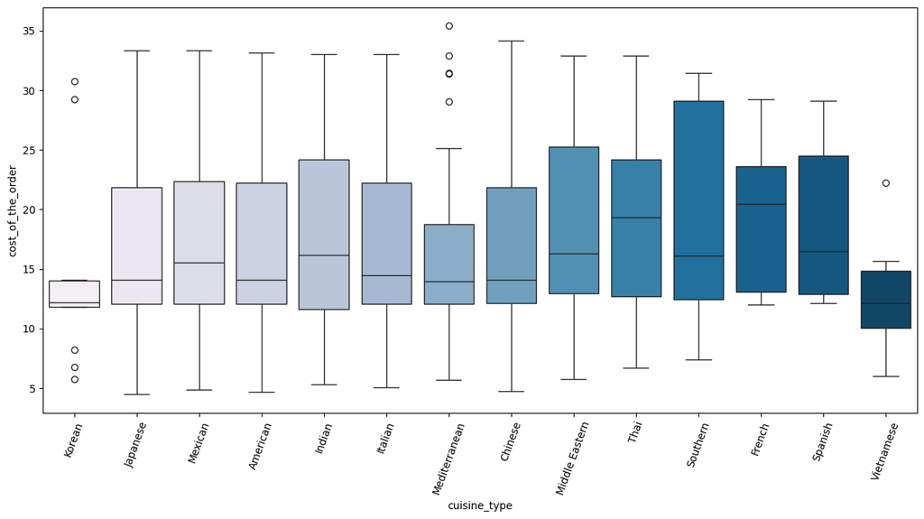

```python
# Relationship between cost of the order and cuisine type
plt.figure(figsize=(15,7))
sns.boxplot(x = "cuisine_type", y = "cost_of_the_order", data = dataframe, palette = 'PuBu', hue = "cuisine_type")
plt.xticks(rotation = 70)
plt.show()
```

Cuisine vs Food Preparation Time

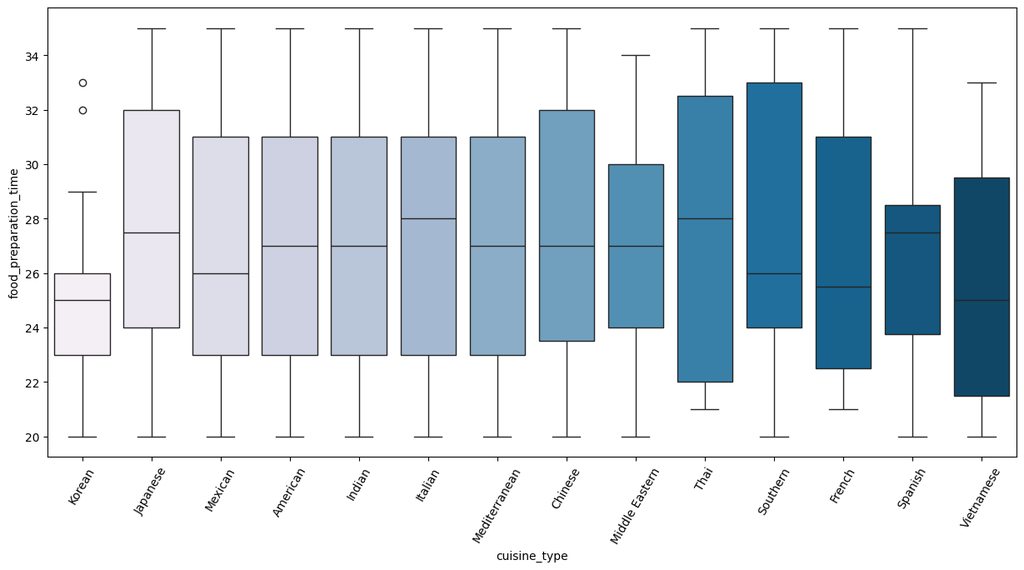

```python
# Relationship between food preparation time and cuisine type
plt.figure(figsize=(15,7))
# Visualize the relationship between food preparation time and cuisine type using boxplot
sns.boxplot(x = "cuisine_type", y = "food_preparation_time", data = dataframe, palette = 'PuBu', hue = "cuisine_type")
plt.xticks(rotation = 60)
plt.show()
```

Day of the Week vs Delivery time

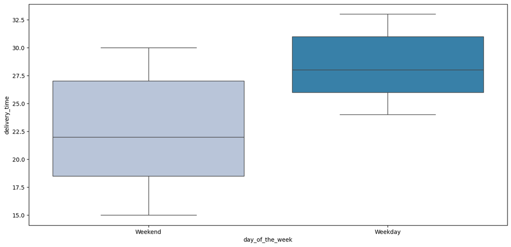

```python
# Relationship between day of the week and delivery time
plt.figure(figsize=(15,7))
#Visualize the relationship between day of the week and delivery time using boxplot
sns.boxplot(x = "day_of_the_week", y = "delivery_time", data = dataframe, palette = 'PuBu', hue = "day_of_the_week")
plt.show()
```

Rating vs Delivery time

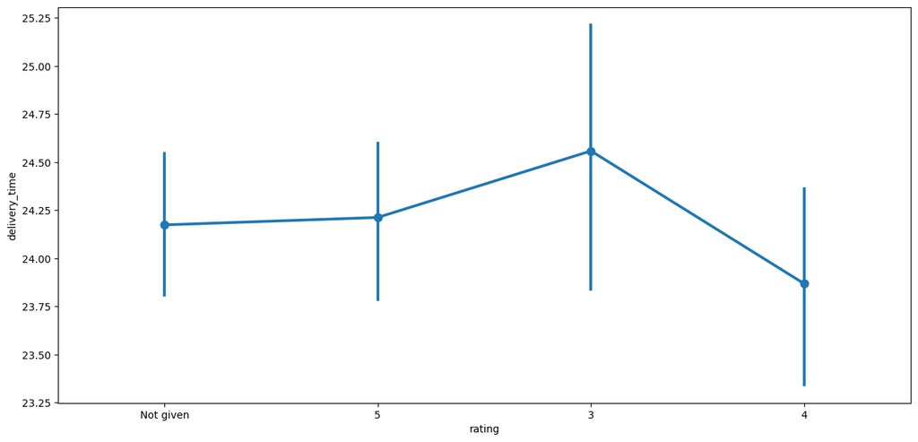

```python
# Relationship between rating and delivery time
plt.figure(figsize=(15, 7))
sns.pointplot(x = 'rating', y = 'delivery_time', data = dataframe)
plt.show()
```

Rating vs Food preparation time

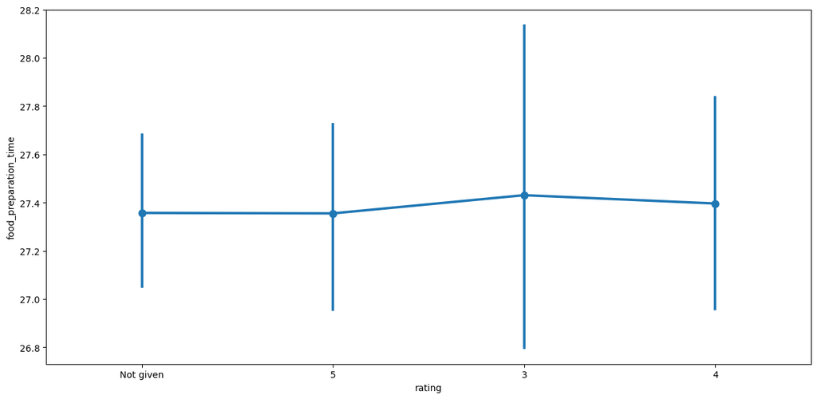

```python
# Relationship between rating and food preparation time using pointplot
plt.figure(figsize=(15, 7))
sns.pointplot(x = 'rating', y = 'food_preparation_time', data = dataframe)
plt.show()
```

Rating vs Cost of the order

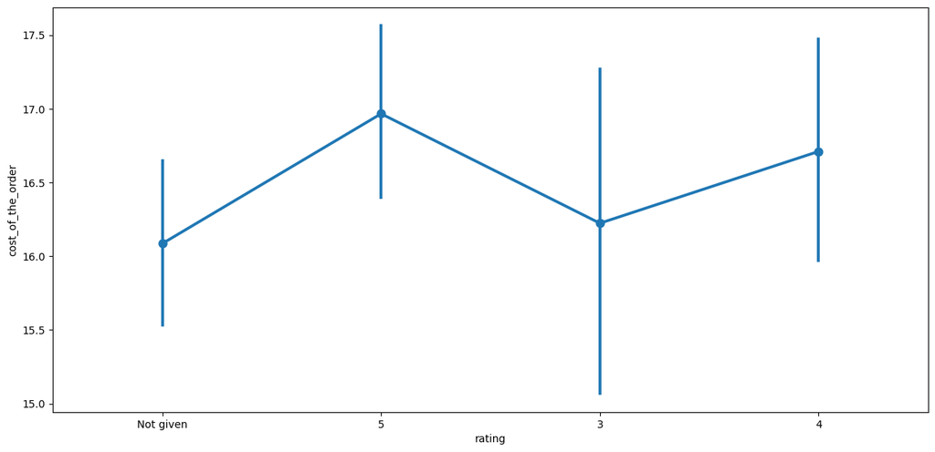

```python
# Relationship between rating and cost of the order using pointplot
plt.figure(figsize=(15, 7))
sns.pointplot(x = 'rating', y = 'cost_of_the_order', data = dataframe)
plt.show()
```

Correlation among variables

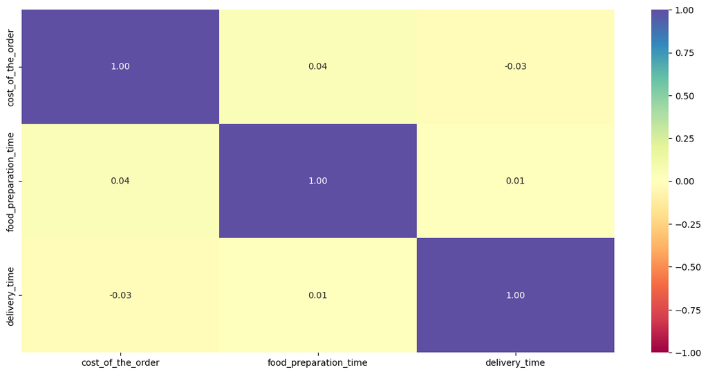

```python
# Plot the heatmap
columns_list = ['cost_of_the_order', 'food_preparation_time', 'delivery_time']
plt.figure(figsize=(15, 7))
sns.heatmap(dataframe[columns_list].corr(), annot=True, vmin=-1, vmax=1, fmt=".2f", cmap="Spectral")
plt.show()
```

### **Question 13:** The company wants to provide a promotional offer in the advertisement of the restaurants. The condition to get the offer is that the restaurants must have a rating count of more than 50 and the average rating should be greater than 4. Find the restaurants fulfilling the criteria to get the promotional offer. [3 marks]

```python
# Write the code here
# Rated restaurants
dataframe_rated = dataframe[dataframe['rating'] != 'Not given'].copy()

# Convert rating column from object to integer
dataframe_rated['rating'] = dataframe_rated['rating'].astype('int')

# Top 5 restaurants with their rating counts
dataframe_rating_count = dataframe_rated.groupby(['restaurant_name'])['rating'].count().sort_values(ascending = False).reset_index()
dataframe_rating_count.head()
```

|  | restaurant_name | rating |
| --- | --- | --- |
| 0 | Shake Shack | 133 |
| 1 | The Meatball Shop | 84 |
| 2 | Blue Ribbon Sushi | 73 |
| 3 | Blue Ribbon Fried Chicken | 64 |
| 4 | RedFarm Broadway | 41 |

```python
# Get the restaurant names that have rating count more than 50
rest_names = dataframe_rating_count[dataframe_rating_count['rating'] > 50]['restaurant_name'] ## Complete the code to get the restaurant names having rating count more than 50

# Get the data of restaurants that have rating count more than 50
dataframe_mean_4 = dataframe_rated[dataframe_rated['restaurant_name'].isin(rest_names)].copy()

# Group the restaurant names with their ratings to find the mean rating of each restaurant
dataframe_mean_4_rating = dataframe_mean_4.groupby(['restaurant_name'])['rating'].mean().sort_values(ascending = False).reset_index().dropna() ## Complete the code to find the mean rating

# data rows average rating greater than 4
df_avg_rating_above_4 = dataframe_mean_4_rating[dataframe_mean_4_rating['rating'] > 4].sort_values(by='rating', ascending=False).reset_index(drop=True)  ## Complete the code to find restaurants with rating > 4

df_avg_rating_above_4
```

|  | restaurant_name | rating |
| --- | --- | --- |
| 0 | The Meatball Shop | 4.511905 |
| 1 | Blue Ribbon Fried Chicken | 4.328125 |
| 2 | Shake Shack | 4.278195 |
| 3 | Blue Ribbon Sushi | 4.219178 |

### **Question 14:** The company charges the restaurant 25% on the orders having cost greater than 20 dollars and 15% on the orders having cost greater than 5 dollars. Find the net revenue generated by the company across all orders. [3 marks]

```python
# Write the code here
#create a function to calculate revenue for each order based on cost of the order
def calculate_revenue(cost):
    if(cost > 20):
      return cost * 0.25
    elif(cost > 5):
      return cost * 0.15
    else:
      return 0

#add a new column 'revenue' for each row
dataframe['revenue'] = dataframe['cost_of_the_order'].apply(calculate_revenue)

#print top 5 rows from dataframe with added new column revenue
dataframe.head()
```

|  | order_id | customer_id | restaurant_name | cuisine_type | cost_of_the_order | day_of_the_week | rating | food_preparation_time | delivery_time | revenue |
| --- | --- | --- | --- | --- | --- | --- | --- | --- | --- | --- |
| 0 | 1477147 | 337525 | Hangawi | Korean | 30.75 | Weekend | Not given | 25 | 20 | 7.6875 |
| 1 | 1477685 | 358141 | Blue Ribbon Sushi Izakaya | Japanese | 12.08 | Weekend | Not given | 25 | 23 | 1.8120 |
| 2 | 1477070 | 66393 | Cafe Habana | Mexican | 12.23 | Weekday | 5 | 23 | 28 | 1.8345 |
| 3 | 1477334 | 106968 | Blue Ribbon Fried Chicken | American | 29.20 | Weekend | 3 | 25 | 15 | 7.3000 |
| 4 | 1478249 | 76942 | Dirty Bird to Go | American | 11.59 | Weekday | 4 | 25 | 24 | 1.7385 |

```python
#print sum of revenue column
net_revenue = dataframe['revenue'].sum()
print("Net revenue generated by the company across all orders :", '$', round(net_revenue, 2))
```

```
Net revenue generated by the company across all orders : $ 6166.3
```

### **Question 15:** The company wants to analyze the total time required to deliver the food. What percentage of orders take more than 60 minutes to get delivered from the time the order is placed? (The food has to be prepared and then delivered.) [2 marks]

```python
# Write the code here
# Add a new column to the dataframe to store the calculated total delivery time
dataframe['total_time_to_deliver'] = dataframe['food_preparation_time'] + dataframe['delivery_time']
dataframe.head()
```

|  | order_id | customer_id | restaurant_name | cuisine_type | cost_of_the_order | day_of_the_week | rating | food_preparation_time | delivery_time | revenue | total_time_to_deliver |
| --- | --- | --- | --- | --- | --- | --- | --- | --- | --- | --- | --- |
| 0 | 1477147 | 337525 | Hangawi | Korean | 30.75 | Weekend | Not given | 25 | 20 | 7.6875 | 45 |
| 1 | 1477685 | 358141 | Blue Ribbon Sushi Izakaya | Japanese | 12.08 | Weekend | Not given | 25 | 23 | 1.8120 | 48 |
| 2 | 1477070 | 66393 | Cafe Habana | Mexican | 12.23 | Weekday | 5 | 23 | 28 | 1.8345 | 51 |
| 3 | 1477334 | 106968 | Blue Ribbon Fried Chicken | American | 29.20 | Weekend | 3 | 25 | 15 | 7.3000 | 40 |
| 4 | 1478249 | 76942 | Dirty Bird to Go | American | 11.59 | Weekday | 4 | 25 | 24 | 1.7385 | 49 |

```python
order_percentage_above_60_minutes = round((dataframe[dataframe['total_time_to_deliver'] > 60].shape[0] / dataframe.shape[0]) * 100, 2)
print("Percentage of orders that take more than 60 minutes to get delivered :", order_percentage_above_60_minutes, '%')
```

```
Percentage of orders that take more than 60 minutes to get delivered : 10.54 %
```

### **Question 16:** The company wants to analyze the delivery time of the orders on weekdays and weekends. How does the mean delivery time vary during weekdays and weekends? [2 marks]

```python
# Write the code here
# Print mean delivery time on weekdays
print('The mean delivery time on weekdays is around',
      round(dataframe[dataframe['day_of_the_week'] == 'Weekday']['delivery_time'].mean()),
     'minutes')


# Print mean delivery time on weekends
print('The mean delivery time on weekends is around',
      round(dataframe[dataframe['day_of_the_week'] == 'Weekend']['delivery_time'].mean()),
     'minutes')
```

```
The mean delivery time on weekdays is around 28 minutes
The mean delivery time on weekends is around 22 minutes
```

### Recommendations:

- We shall have data in additional columns for how much the amount comes as commission to the company for every order
- We shall add distance in miles between restaurant and the delivery point to have relationship of delivery time to distance in weekdays and weekends to access. We shall have these data analysis which could be really helpful for the business to increase the net revenue
- if cost of order is what company is charging from the customer, then we shall have additional data for the cost of order the restaurant charges for each order. Commission to the company can be another column in the dataset
- Can include the driver name as well with each order who delivered the food and can have relationship of driver to the rating he gets and his delivery speed etc.
- Customer's location information (city they reside) could help to determine from which city most of the orders are being placed in weekdays or weekends to determine the graph showing most important city of revenue. So that more drivers could serve those locations and could decrease delivery time
- Each driver could take multiple orders if the customer is on the way while delivering one order to save delivery time. May need to have similar route orders if demographic (location) information is added for every order in dataset
- delivery instructions can be saved and can produced if the same customer makes the next order to fetch and display while taking orders (optional)